# Overview

## Introduction

We present here some preliminary experiments in order to give an overview of the possibilities of analysis of world region based on the Food Balance Sheets (FBS) published by FAO.

## Sources

We use in a first step the most recent data produced by FAO, covering the period 2010 to present. We will further used another database covering the period 1963-2013 but not immediately as they are some difficulties for the harmonization of the two databases.

### Geometry

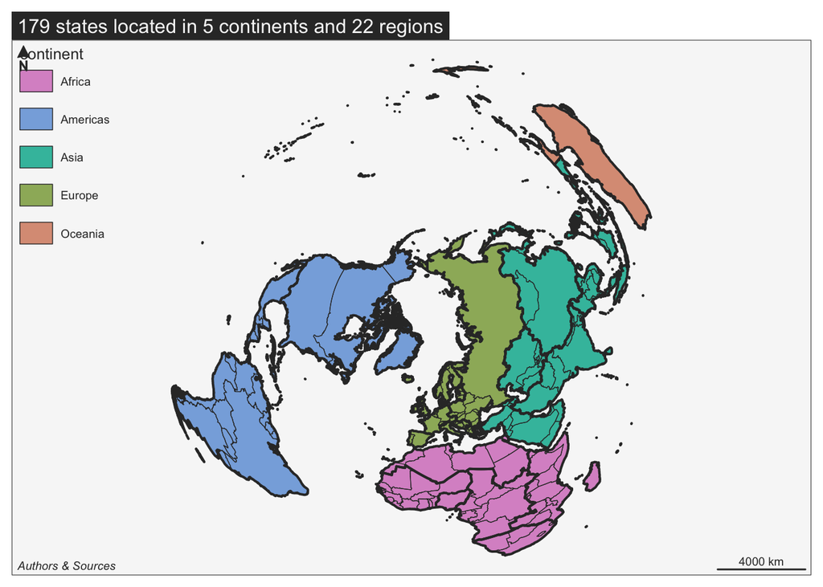

### Population

The FAO has collected variables from other sources (UN, Worldbank,…) in order to get estimates of the population of territorial units for which the FBS has been collected. We eliminate the unit called *China* (F351) because it is the sum of four other units present in the database *China Mainland* (CHN), *Hong Kong* (HKG), *Macao* (MAC) and … *Taïwan* (TWN). This duplication of data is clearly not practical from statistical point of view. But we can easily imagine why the republic of China has obliged the FAO to proceed this way …

Population 2010-2022 - Long format

| iso3 | year | pop | name | region | continent |
| --- | --- | --- | --- | --- | --- |
| AFG | 2010 | 28189.67 | Afghanistan | Southern Asia | Asia |
| AFG | 2011 | 29249.16 | Afghanistan | Southern Asia | Asia |
| AFG | 2012 | 30466.48 | Afghanistan | Southern Asia | Asia |
| AFG | 2013 | 31541.21 | Afghanistan | Southern Asia | Asia |
| AFG | 2014 | 32716.21 | Afghanistan | Southern Asia | Asia |
| AFG | 2015 | 33753.50 | Afghanistan | Southern Asia | Asia |

The dataset is in long format but can easily be transformed in wide format :

Population 2010-2022 - wide format

| iso3 | 2010 | 2011 | 2012 | 2013 | 2014 | 2015 | 2016 | 2017 | 2018 | 2019 | 2020 | 2021 | 2022 |
| --- | --- | --- | --- | --- | --- | --- | --- | --- | --- | --- | --- | --- | --- |
| AFG | 28189.67 | 29249.16 | 30466.48 | 31541.21 | 32716.21 | 33753.50 | 34636.21 | 35643.42 | 36686.78 | 37769.50 | 38972.23 | 40099.46 | 41128.77 |
| AGO | 23364.19 | 24259.11 | 25188.29 | 26147.00 | 27128.34 | 28127.72 | 29154.75 | 30208.63 | 31273.53 | 32353.59 | 33428.49 | 34503.77 | 35588.99 |
| ALB | 2913.40 | 2900.65 | 2892.19 | 2887.01 | 2884.10 | 2882.48 | 2881.06 | 2879.36 | 2877.01 | 2873.88 | 2866.85 | 2854.71 | 2842.32 |
| ARE | 8481.77 | 8575.20 | 8664.97 | 8751.85 | 8835.95 | 8916.90 | 8994.26 | 9068.30 | 9140.17 | 9211.66 | 9287.29 | 9365.15 | 9441.13 |
| ARG | 41100.12 | 41520.74 | 41952.36 | 42388.27 | 42824.05 | 43257.07 | 43668.24 | 44054.62 | 44413.60 | 44745.52 | 45036.03 | 45276.78 | 45510.32 |
| ARM | 2946.29 | 2928.98 | 2914.42 | 2901.39 | 2889.93 | 2878.59 | 2865.84 | 2851.92 | 2836.56 | 2820.60 | 2805.61 | 2790.97 | 2780.47 |

Some missing values can be observed but only for a limited number of territorial units :

| iso3 | name | available | max | pct |
| --- | --- | --- | --- | --- |
| BHR | Bahrain | 4 | 13 | 30.8 |
| BTN | Bhutan | 4 | 13 | 30.8 |
| FSM | Micronesia (Federated States of) | 4 | 13 | 30.8 |
| MHL | Marshall Islands | 4 | 13 | 30.8 |
| NRU | Nauru | 4 | 13 | 30.8 |
| QAT | Qatar | 4 | 13 | 30.8 |
| SSD | South Sudan | 4 | 13 | 30.8 |
| TON | Tonga | 4 | 13 | 30.8 |
| PRK | Democratic People’s Republic of Korea | 9 | 13 | 69.2 |
| SDN | Sudan | 11 | 13 | 84.6 |

We elaborate a map of the average share of world population over the period :

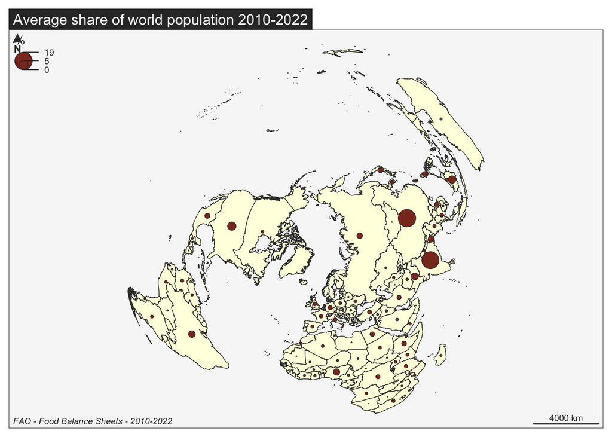

### Food Balance Sheet (Kcal)

We select the Food Balance Sheet (FBS) measured in Kcal/capita/day which is one of the four possible option of measure. Initialy the table has a lot of columns :

#### Structure of data

FBS 2010-2022 - Raw data

| Domain Code | Domain | Area Code (ISO3) | Area | Element Code | Element | Item Code (FBS) | Item | Year Code | Year | Unit | Value | Flag | Flag Description | Note |
| --- | --- | --- | --- | --- | --- | --- | --- | --- | --- | --- | --- | --- | --- | --- |
| FBS | Food Balances (2010-) | AFG | Afghanistan | 664 | Food supply (kcal/capita/day) | S2511 | Wheat and products | 2010 | 2010 | kcal/cap/d | 1469.35 | E | Estimated value | NA |
| FBS | Food Balances (2010-) | AFG | Afghanistan | 664 | Food supply (kcal/capita/day) | S2511 | Wheat and products | 2011 | 2011 | kcal/cap/d | 1407.04 | E | Estimated value | NA |
| FBS | Food Balances (2010-) | AFG | Afghanistan | 664 | Food supply (kcal/capita/day) | S2511 | Wheat and products | 2012 | 2012 | kcal/cap/d | 1358.96 | E | Estimated value | NA |
| FBS | Food Balances (2010-) | AFG | Afghanistan | 664 | Food supply (kcal/capita/day) | S2511 | Wheat and products | 2013 | 2013 | kcal/cap/d | 1390.57 | E | Estimated value | NA |
| FBS | Food Balances (2010-) | AFG | Afghanistan | 664 | Food supply (kcal/capita/day) | S2511 | Wheat and products | 2014 | 2014 | kcal/cap/d | 1362.96 | E | Estimated value | NA |
| FBS | Food Balances (2010-) | AFG | Afghanistan | 664 | Food supply (kcal/capita/day) | S2511 | Wheat and products | 2015 | 2015 | kcal/cap/d | 1371.68 | E | Estimated value | NA |
| FBS | Food Balances (2010-) | AFG | Afghanistan | 664 | Food supply (kcal/capita/day) | S2511 | Wheat and products | 2016 | 2016 | kcal/cap/d | 1402.60 | E | Estimated value | NA |
| FBS | Food Balances (2010-) | AFG | Afghanistan | 664 | Food supply (kcal/capita/day) | S2511 | Wheat and products | 2017 | 2017 | kcal/cap/d | 1405.12 | E | Estimated value | NA |
| FBS | Food Balances (2010-) | AFG | Afghanistan | 664 | Food supply (kcal/capita/day) | S2511 | Wheat and products | 2018 | 2018 | kcal/cap/d | 1365.34 | E | Estimated value | NA |
| FBS | Food Balances (2010-) | AFG | Afghanistan | 664 | Food supply (kcal/capita/day) | S2511 | Wheat and products | 2019 | 2019 | kcal/cap/d | 1346.93 | E | Estimated value | NA |

We decide to simplify a bit the structure and to reduce the number of columns like this :

FBS 2010-2022 - Simplified

| year | iso3 | item | item_name | K |
| --- | --- | --- | --- | --- |
| 2010 | AFG | S2511 | Wheat and products | 1469.35 |
| 2011 | AFG | S2511 | Wheat and products | 1407.04 |
| 2012 | AFG | S2511 | Wheat and products | 1358.96 |
| 2013 | AFG | S2511 | Wheat and products | 1390.57 |
| 2014 | AFG | S2511 | Wheat and products | 1362.96 |
| 2015 | AFG | S2511 | Wheat and products | 1371.68 |
| 2016 | AFG | S2511 | Wheat and products | 1402.60 |
| 2017 | AFG | S2511 | Wheat and products | 1405.12 |
| 2018 | AFG | S2511 | Wheat and products | 1365.34 |
| 2019 | AFG | S2511 | Wheat and products | 1346.93 |

#### Hierarchisation of food items

In the initial format delivered by FAO, the classification of items is a mixture of aggregates at different hierarchical level. Here we have decided to collect only the lowest level and to add a hierarchy of aggregation levels based on the table below :

Hierarchy of food items

| i0 | name_i0 | i1 | name_i1 | i2 | name_i2 | i | name_i |
| --- | --- | --- | --- | --- | --- | --- | --- |
| 2901 | TOTAL | 2903 | VEGETALE PRODUCTS | 2905 | CEREALS (excluding beer) | 2511 | WHEAT & products |
| 2901 | TOTAL | 2903 | VEGETALE PRODUCTS | 2905 | CEREALS (excluding beer) | 2513 | BARLEY & products |
| 2901 | TOTAL | 2903 | VEGETALE PRODUCTS | 2905 | CEREALS (excluding beer) | 2514 | MAIZE & products |
| 2901 | TOTAL | 2903 | VEGETALE PRODUCTS | 2905 | CEREALS (excluding beer) | 2515 | RYE & products |
| 2901 | TOTAL | 2903 | VEGETALE PRODUCTS | 2905 | CEREALS (excluding beer) | 2516 | OATS & products |
| 2901 | TOTAL | 2903 | VEGETALE PRODUCTS | 2905 | CEREALS (excluding beer) | 2517 | MILLET & products |
| 2901 | TOTAL | 2903 | VEGETALE PRODUCTS | 2905 | CEREALS (excluding beer) | 2518 | SORGHUM & products |
| 2901 | TOTAL | 2903 | VEGETALE PRODUCTS | 2905 | CEREALS (excluding beer) | 2520 | CEREALS, OTHER & products |
| 2901 | TOTAL | 2903 | VEGETALE PRODUCTS | 2907 | STARCHY ROOTS | 2531 | POTATOES & products |
| 2901 | TOTAL | 2903 | VEGETALE PRODUCTS | 2907 | STARCHY ROOTS | 2532 | CASSAVA & products |
| 2901 | TOTAL | 2903 | VEGETALE PRODUCTS | 2907 | STARCHY ROOTS | 2533 | SWEET POTATOES |
| 2901 | TOTAL | 2903 | VEGETALE PRODUCTS | 2907 | STARCHY ROOTS | 2534 | ROOTS, OTHER & products |
| 2901 | TOTAL | 2903 | VEGETALE PRODUCTS | 2907 | STARCHY ROOTS | 2535 | YAMS |
| 2901 | TOTAL | 2903 | VEGETALE PRODUCTS | 2908 | SUGAR CROPS | 2536 | SUGAR CANE |
| 2901 | TOTAL | 2903 | VEGETALE PRODUCTS | 2908 | SUGAR CROPS | 2537 | SUGAR BEET |
| 2901 | TOTAL | 2903 | VEGETALE PRODUCTS | 2909 | SWEETENERS | 2541 | SUGAR NON-CENTRIFUGAL |
| 2901 | TOTAL | 2903 | VEGETALE PRODUCTS | 2909 | SWEETENERS | 2542 | SUGAR (RAW EQUIVALENT) & products |
| 2901 | TOTAL | 2903 | VEGETALE PRODUCTS | 2909 | SWEETENERS | 2543 | SWEETENERS, NES & products |
| 2901 | TOTAL | 2903 | VEGETALE PRODUCTS | 2911 | PULSES | 2546 | BEANS DRY |
| 2901 | TOTAL | 2903 | VEGETALE PRODUCTS | 2911 | PULSES | 2547 | PEAS DRY |
| 2901 | TOTAL | 2903 | VEGETALE PRODUCTS | 2911 | PULSES | 2549 | PULSES, OTHER & products |
| 2901 | TOTAL | 2903 | VEGETALE PRODUCTS | 2912 | TREENUTS | 2551 | NUTS & products |
| 2901 | TOTAL | 2903 | VEGETALE PRODUCTS | 2913 | OILCROPS | 2552 | GROUNDNUTS & products |
| 2901 | TOTAL | 2903 | VEGETALE PRODUCTS | 2913 | OILCROPS | 2555 | SOYBEANS & products |
| 2901 | TOTAL | 2903 | VEGETALE PRODUCTS | 2913 | OILCROPS | 2557 | SUNFLOWERSEED |
| 2901 | TOTAL | 2903 | VEGETALE PRODUCTS | 2913 | OILCROPS | 2558 | RAPE AND MUSTARDSEED & products |
| 2901 | TOTAL | 2903 | VEGETALE PRODUCTS | 2913 | OILCROPS | 2559 | COTTONSEED |
| 2901 | TOTAL | 2903 | VEGETALE PRODUCTS | 2913 | OILCROPS | 2560 | COCONUTS (INCL. COPRA) & products |
| 2901 | TOTAL | 2903 | VEGETALE PRODUCTS | 2913 | OILCROPS | 2561 | SESAMESEED |
| 2901 | TOTAL | 2903 | VEGETALE PRODUCTS | 2913 | OILCROPS | 2562 | PALM KERNELS & products |

[output cut: 67 more lines]

### Synthetic data base

We decide to add the hiearachy of food items but also the hierarchy of geographical levels and the population in a single file where it will be possible to realize easily all types of analysis.

Structure of multilevel database

| s | t | name_s | i | name_i | Kist | Pst | i0 | name_i0 | i1 | name_i1 | i2 | name_i2 | reg_s | cont_s |
| --- | --- | --- | --- | --- | --- | --- | --- | --- | --- | --- | --- | --- | --- | --- |
| AFG | 2010 | Afghanistan | 2511 | Wheat and products | 1469.35 | 28189.67 | 2901 | TOTAL | 2903 | VEGETALE PRODUCTS | 2905 | CEREALS (excluding beer) | Southern Asia | Asia |
| AFG | 2011 | Afghanistan | 2511 | Wheat and products | 1407.04 | 29249.16 | 2901 | TOTAL | 2903 | VEGETALE PRODUCTS | 2905 | CEREALS (excluding beer) | Southern Asia | Asia |
| AFG | 2012 | Afghanistan | 2511 | Wheat and products | 1358.96 | 30466.48 | 2901 | TOTAL | 2903 | VEGETALE PRODUCTS | 2905 | CEREALS (excluding beer) | Southern Asia | Asia |
| AFG | 2013 | Afghanistan | 2511 | Wheat and products | 1390.57 | 31541.21 | 2901 | TOTAL | 2903 | VEGETALE PRODUCTS | 2905 | CEREALS (excluding beer) | Southern Asia | Asia |
| AFG | 2014 | Afghanistan | 2511 | Wheat and products | 1362.96 | 32716.21 | 2901 | TOTAL | 2903 | VEGETALE PRODUCTS | 2905 | CEREALS (excluding beer) | Southern Asia | Asia |
| AFG | 2015 | Afghanistan | 2511 | Wheat and products | 1371.68 | 33753.50 | 2901 | TOTAL | 2903 | VEGETALE PRODUCTS | 2905 | CEREALS (excluding beer) | Southern Asia | Asia |

```
[1] "data.table" "data.frame"
```

As we can see the database is a “cube” with three elementary dimensions :

- $t$ : the year of observation
- $s$ : the state concerned
- $i$ : the item of food at the elementary level.

Two quantitative indicators are available :

- $F_{ijt}$ : the consumption of food from item $i$ in state $s$ during the year $t$ measured in kcal/capita/day
- $P_{it}$ : the estimated population of state $i$ during the year $t$ which can be used as weighting criteria for the procedure of agregation if we want to obtain corrected value at world, continental or regional level.

The following columns are different keys of aggregation for food items (i0, i1,i2) or for spatial units (reg, cont)

## Test of the database

### Global Food Balance in 2021

We can firstly try to compute some global values, for example in 2021.

#### World level

Food ration in Kcal by day at world level in 2021

| Total Kcal | Total Population | Kcal/capita |
| --- | --- | --- |
| 2.3377e+10 | 7850358 | 2977.826 |

#### Continental level

[output not shown]

Food ration in Kcal by day at continental level in 2021

| Continent | Kcal | Population | % Kcal | % Pop | Kcal/capita | index 100 = World |
| --- | --- | --- | --- | --- | --- | --- |
| Africa | 3569201324 | 1386569 | 15.27 | 17.66 | 2574 | 86 |
| Asia | 13636915976 | 4650890 | 58.33 | 59.24 | 2932 | 98 |
| Oceania | 136859879 | 44165 | 0.59 | 0.56 | 3099 | 104 |
| Americas | 3467937046 | 1026254 | 14.83 | 13.07 | 3379 | 113 |
| Europe | 2566083186 | 742480 | 10.98 | 9.46 | 3456 | 116 |

- **Comment** : At continental level, we add some columns in order to compare for each continent the share of population and the share of food consumption measured in Kcal. According to our results, the lowest level of consumption is observed in **Africa** which account for 17.7% of world population but only 15.3% of food consumption mesured in Kcal. The level of consumption of Africa is at index 86 i.e -14% lower than the world average. On the contrary, Europe is at index 116 which is +16% higher than the world average. As inprevious case, we obtain the same figure than the FAO report.

#### Regional level

[output not shown]

Food ration in Kcal by day at regional level in 2021

| region | Kcal | Population | % Kcal | % Pop | Kcal/capita | index 100 = World |
| --- | --- | --- | --- | --- | --- | --- |
| Eastern Africa | 1012076340 | 445491 | 4.33 | 5.67 | 2272 | 76 |
| Melanesia | 27842761 | 12189 | 0.12 | 0.16 | 2284 | 77 |
| Middle Africa | 458268899 | 199382 | 1.96 | 2.54 | 2298 | 77 |
| Southern Asia | 5111089355 | 1989452 | 21.86 | 25.34 | 2569 | 86 |
| Western Africa | 1109898236 | 418539 | 4.75 | 5.33 | 2652 | 89 |
| Southern Africa | 185122608 | 67985 | 0.79 | 0.87 | 2723 | 91 |
| Caribbean | 112474137 | 39486 | 0.48 | 0.50 | 2848 | 96 |
| South-Eastern Asia | 1940288698 | 669410 | 8.30 | 8.53 | 2899 | 97 |
| Polynesia | 1868998 | 629 | 0.01 | 0.01 | 2972 | 100 |
| Micronesia | 885953 | 297 | 0.00 | 0.00 | 2987 | 100 |
| South America | 1348459257 | 433953 | 5.77 | 5.53 | 3107 | 104 |
| Central America | 558610711 | 177662 | 2.39 | 2.26 | 3144 | 106 |
| Western Asia | 876043990 | 278406 | 3.75 | 3.55 | 3147 | 106 |
| Northern Africa | 803835241 | 255172 | 3.44 | 3.25 | 3150 | 106 |
| Central Asia | 239371457 | 75898 | 1.02 | 0.97 | 3154 | 106 |
| Eastern Europe | 971750272 | 290964 | 4.16 | 3.71 | 3340 | 112 |
| Eastern Asia | 5470122478 | 1637725 | 23.40 | 20.86 | 3340 | 112 |
| Northern Europe | 358664987 | 105888 | 1.53 | 1.35 | 3387 | 114 |
| Australia and New Zealand | 106262168 | 31051 | 0.45 | 0.40 | 3422 | 115 |
| Southern Europe | 530564557 | 150323 | 2.27 | 1.91 | 3530 | 119 |
| Western Europe | 705103371 | 195306 | 3.02 | 2.49 | 3610 | 121 |
| Northern America | 1448392941 | 375153 | 6.20 | 4.78 | 3861 | 130 |

- **Comment** : We can replicate the same analysis at the level of the 22 regions defined by UN as subdivisions of continents. We can reveal more important inequalities with a lowest level of 76 (-24% of world average) in Eastern Africa and an highest level of 130 (+30% of world average) in Northern America. These results are consistent with the publication of the FAO and the litterature on the subject.